# Merging metadata and recount_brain

Leonardo Collado-Torres and Ashkaun Razmara

Lieber Institute for Brain Development, Johns Hopkins Medical Campus  
Center for Computational Biology, Johns Hopkins University

lcolladotor@gmail.com

13 November 2020

This document contains the code that creates the `recount_brain` table by merging all the curated SRA metadata tables created by Ashkaun Razmara.

# 1 Setup

First, we need some packages.

```r
library('devtools')
library('recount')
library('knitcitations')
library('BiocStyle')
```

Next we setup the citation information.

```r
## Load knitcitations with a clean bibliography
cleanbib()
cite_options(hyperlink = 'to.doc', citation_format = 'text', style = 'html')
# Note links won't show for now due to the following issue
# https://github.com/cboettig/knitcitations/issues/63

## Write bibliography information
bib <- c(
    R = citation(),
    BiocStyle = citation('BiocStyle'),
    devtools = citation('devtools'),
    knitcitations = citation('knitcitations'),
    knitr = citation('knitr')[3],
    recount = citation('recount')[1],
    rmarkdown = citation('rmarkdown')[1]
)

write.bibtex(bib, file = 'merging_data.bib')
```

# 2 Read tables

This code finds all the SRA metadata tables and reads them into R.

```r
## Find table files and name them by project id
table_files <- dir('../SRA_metadata', pattern = '.csv$', full.names = TRUE)
names(table_files) <- sapply(strsplit(table_files, ', '), function(x) {
    strsplit(x[2], '-Table')[[1]][1] })

## Read the table files
table_content <- lapply(table_files, read.csv, header = TRUE,
    stringsAsFactors = FALSE, na.strings = c('NA', ''))
```

Having read the tables, we can check how frequent are some variables that we will ignore in `recount_brain`. Most of these variables are rare and just present in a handful of studies. Others like `Sequencing.Kit` are present frequently as column names but mostly made up of NAs due to how we constructed the SRA metadata tables.

```r
## Define the main variables we want from all studies
main_variables <- c('Center_Name_s', 'Library_Name_s', 'AvgSpotLen_l',
    'BioSample_s', 'Experiment_s', 'MBases_l', 'MBytes_l', 'Run_s',
    'SRA_Sample_s', 'Sample_Name_s', 'BioProject_s', 'Consent_s',
    'InsertSize_l', 'Instrument_s', 'LibraryLayout_s', 'LibrarySelection_s',
    'LibrarySource_s', 'LoadDate_s', 'Platform_s', 'ReleaseDate_s',
    'SRA_Study_s', 'Assay_Type_s', 'Organism_s', 'Brain.Bank', 'Sex',
    'Age.Units', 'Age', 'Development', 'Race', 'Sample.Origin', 'Cell.Line',
    'Tissue.Site.1', 'Tissue.Site.2', 'Tissue.Site.3', 'Brodmann.Area',
    'Hemisphere', 'Disease.Status', 'Disease', 'Tumor.Type',
    'Clinical.Stage.1', 'Clinical.Stage.2', 'Pathology', 'Viability',
    'Preparation', 'PMI', 'PMI.Units', 'RIN')

## Check whether the variables are part of our set or extra variables
## that we will ignore.
check_vars <- lapply(table_content , function(tab) {
    present <- tolower(colnames(tab))[tolower(colnames(tab)) %in%
        tolower(main_variables)]
    tobeignored <- tolower(colnames(tab))[!tolower(colnames(tab)) %in%
        tolower(main_variables)]
    return(list(present = present, tobeignored = tobeignored))
})
## Variables that will be ignored
sort(table(unlist(sapply(check_vars, '[[', 'tobeignored'))), decreasing = TRUE)
```

```
##
##                                   x                      sequencing.kit
##                                  62                                  61
##                                 x.1                                 x.2
##                                  35                                  26
##                       source_name_s                            tissue_s
##                                  24                                  18
##                                 x.3              biomaterial_provider_s
##                                  11                                  10
##                    biosamplemodel_s                           isolate_s
##                                  10                                   9
##                                 x.4                         cell_type_s
##                                   8                                   6
##                      assemblyname_s                            organism
##                                   5                                   4
##                          assay.type                     disease_state_s
##                                   3                                   3
##                  molecule_subtype_s                           barcode_s
##                                   3                                   2
##                         cell_line_s                     clip_antibody_s
##                                   2                                   2
##                           disease_s                          genotype_s
##                                   2                                   2
##                      health_state_s                             label_s
##                                   2                                   2
##                librarypreparation_s                         sample_id_s
##                                   2                                   2
##                            strain_s                       tissue_type_s
##                                   2                                   2
##                      age_of_onset_s                     apoe_genotype_s
##                                   1                                   1
##                            base.gb.                          base.gb..1
##                                   1                                   1
##                          base.gb..2                       braak_stage_s
##                                   1                                   1
##                      brain_region_s                               cag_s
##                                   1                                   1
##                      cell_subtype_s                derived_cell_typed_s
##                                   1                                   1
##                 development_stage_s                         diagnosis_s
```

[output cut: 36 more lines]

```
##                                   1                                   1
##                       seqc_sample_s                              site_s
##                                   1                                   1
##                            slc26a11 specimen_with_known_storage_state_s
##                                   1                                   1
##                             stage_s                     subject_group_s
##                                   1                                   1
##                        subject_id_s                               tacc3
##                                   1                                   1
##                tissue_compartment_s                   transduced_with_s
##                                   1                                   1
##                         treatment_s                       tumor_stage_s
##                                   1                                   1
##                   vonsattel_grade_s                                 x.5
##                                   1                                   1
```

```r
## Check that we are not missing any due to spelling issues
stopifnot(all(
    !names(table(unlist(sapply(check_vars, '[[', 'tobeignored')))) %in%
    tolower(main_variables)))
```

Next we can keep just the main variables of interest.

```r
## Keep only the main variables
table_content <- lapply(table_content , function(tab) {
    tab[, colnames(tab) %in% main_variables]
})
```

We can then compute some summary statistics per variable for each study, like what is the percent of missing observations.

```r
## Compute some statistics per variable and study
table_cols <- do.call(rbind, lapply(seq_len(length(table_content)), function(i) {
  tab <- table_content[[i]]
  df <- data.frame(columns = colnames(tab), number_na = sapply(tab, function(var) { sum(is.na(var))}), n = nrow(tab), study = names(table_content)[i], stringsAsFactors = FALSE)
  df$percent_na <- df$number_na / df$n * 100
  df$number_obs <- df$n - df$number_na
  df$percent_obs <- 100 - df$percent_na
  rownames(df) <- NULL
  return(df)
}))

## Explore the summary statistics
dim(table_cols)
```

```
## [1] 2856    7
```

```r
summary(table_cols)
```

```
##    columns            number_na             n              study
##  Length:2856        Min.   :   0.00   Min.   :   4.00   Length:2856
##  Class :character   1st Qu.:   0.00   1st Qu.:   8.00   Class :character
##  Mode  :character   Median :   0.00   Median :  15.00   Mode  :character
##                     Mean   :  30.35   Mean   :  71.41
##                     3rd Qu.:   8.00   3rd Qu.:  25.00
##                     Max.   :2898.00   Max.   :2898.00
##    percent_na      number_obs       percent_obs
##  Min.   :  0.0   Min.   :   0.00   Min.   :  0.0
##  1st Qu.:  0.0   1st Qu.:   0.00   1st Qu.:  0.0
##  Median :  0.0   Median :   8.00   Median :100.0
##  Mean   : 35.1   Mean   :  41.06   Mean   : 64.9
##  3rd Qu.:100.0   3rd Qu.:  18.00   3rd Qu.:100.0
##  Max.   :100.0   Max.   :2898.00   Max.   :100.0
```

```r
## Most commonly observed variables accross all studies
sort(table(table_cols$columns), decreasing = TRUE)
```

```
##
##                Age          Age.Units       AvgSpotLen_l        BioSample_s
##                 62                 62                 62                 62
##         Brain.Bank      Brodmann.Area          Cell.Line   Clinical.Stage.1
##                 62                 62                 62                 62
##   Clinical.Stage.2          Consent_s        Development            Disease
##                 62                 62                 62                 62
##     Disease.Status       Experiment_s         Hemisphere       InsertSize_l
##                 62                 62                 62                 62
##       Instrument_s    LibraryLayout_s LibrarySelection_s    LibrarySource_s
##                 62                 62                 62                 62
##         LoadDate_s           MBases_l           MBytes_l          Pathology
##                 62                 62                 62                 62
##         Platform_s                PMI          PMI.Units        Preparation
##                 62                 62                 62                 62
##               Race      ReleaseDate_s                RIN              Run_s
##                 62                 62                 62                 62
##      Sample.Origin                Sex       SRA_Sample_s        SRA_Study_s
##                 62                 62                 62                 62
##      Tissue.Site.1      Tissue.Site.2      Tissue.Site.3         Tumor.Type
##                 62                 62                 62                 62
##          Viability       BioProject_s      Center_Name_s      Sample_Name_s
##                 62                 61                 60                 60
##       Assay_Type_s         Organism_s     Library_Name_s
##                 59                 58                 16
```

```r
## now in percent
round(sort(table(table_cols$columns), decreasing = TRUE) /
    length(table_content) * 100, 2)
```

```
##
##                Age          Age.Units       AvgSpotLen_l        BioSample_s
##             100.00             100.00             100.00             100.00
##         Brain.Bank      Brodmann.Area          Cell.Line   Clinical.Stage.1
##             100.00             100.00             100.00             100.00
##   Clinical.Stage.2          Consent_s        Development            Disease
##             100.00             100.00             100.00             100.00
##     Disease.Status       Experiment_s         Hemisphere       InsertSize_l
##             100.00             100.00             100.00             100.00
##       Instrument_s    LibraryLayout_s LibrarySelection_s    LibrarySource_s
##             100.00             100.00             100.00             100.00
##         LoadDate_s           MBases_l           MBytes_l          Pathology
##             100.00             100.00             100.00             100.00
##         Platform_s                PMI          PMI.Units        Preparation
##             100.00             100.00             100.00             100.00
##               Race      ReleaseDate_s                RIN              Run_s
##             100.00             100.00             100.00             100.00
##      Sample.Origin                Sex       SRA_Sample_s        SRA_Study_s
##             100.00             100.00             100.00             100.00
##      Tissue.Site.1      Tissue.Site.2      Tissue.Site.3         Tumor.Type
##             100.00             100.00             100.00             100.00
##          Viability       BioProject_s      Center_Name_s      Sample_Name_s
##             100.00              98.39              96.77              96.77
##       Assay_Type_s         Organism_s     Library_Name_s
##              95.16              93.55              25.81
```

```r
## Example of how we can explore the percent NA for the Age variable
#boxplot(percent_na ~ columns, data = table_cols, las = 2)
#hist(subset(table_cols, columns == 'Age')$percent_na)
table(subset(table_cols, columns == 'Age')$percent_na)
```

```
##
##                0 0.72992700729927 4.08163265306122              100
##               28                1                1               32
```

```r
#summary(subset(table_cols, columns == 'Age')$percent_na)
```

# 3 Merging tables

Having read and filtered the tables, we can now proceed to merging them. This is how we create the `recount_brain` table.

```r
## Get the unique columns
unique_cols <- unique(table_cols$columns)
## Sort by percent NA
unique_cols_sorted <- tolower(names(sort(tapply(table_cols$percent_na,
    table_cols$columns, mean))))

## Build a new set of tables by study with all the columns
table_new <- lapply(table_content, function(tab) {
    colnames(tab) <- tolower(colnames(tab))
    missing_cols <- unique_cols[!unique_cols %in% colnames(tab)]
    if(length(missing_cols) > 0) {
        df_add <- as.data.frame(matrix(NA, nrow = nrow(tab), ncol = length(missing_cols)))
        colnames(df_add) <- missing_cols
        df_new <- cbind(tab, df_add)
        colnames(df_new) <- tolower(colnames(df_new))
        res <- df_new[, match(unique_cols_sorted, colnames(df_new))]
    } else {
        res <- tab
    }
    return(res)
})

## Finally merge them all
recount_brain <- do.call(rbind, table_new)
```

# 4 Merge with recount

Now that we have the `recount_brain` table, we can now check if the samples are present in `recount` ([Collado-Torres, Nellore, Kammers, Ellis, et al., 2017](http://www.nature.com/nbt/journal/v35/n4/full/nbt.3838.html)) and save the data which can then be accessed easily thanks to `recount::add_metadata('recount_brain')`.

```r
## Check which samples are in recount
m <- all_metadata('sra')
```

```
## 2020-11-13 16:24:06 downloading the metadata to /tmp/RtmpK9pZcs/metadata_clean_sra.Rdata
```

```r
map <- match(m$run, recount_brain$run_s)
table(!is.na(map))
```

```
##
## FALSE  TRUE
## 46885  3214
```

```r
map_r <- match(recount_brain$run_s, m$run)
table(!is.na(map_r))
```

```
##
## FALSE  TRUE
##  1217  3214
```

```r
## Add whether the sample is present in recount
recount_brain$present_in_recount <- !is.na(map_r)

## Sort alphabetically and change dots for underscores
#recount_brain <- recount_brain[, sort(colnames(recount_brain))]
colnames(recount_brain) <- gsub('\\.', '_', colnames(recount_brain))

## Fix some issues
recount_brain$sex <- tolower(recount_brain$sex)

for(i in which(sapply(recount_brain, class) == 'character')) {
    if(any(grepl('[[:space:]]+$', recount_brain[, i]))) {
        recount_brain[, i] <- gsub('[[:space:]]+$', '', recount_brain[, i])
    }
}

## Final dimensions of recount_brain
dim(recount_brain)
```

```
## [1] 4431   48
```

```r
## Save the data
save(recount_brain, file = 'recount_brain_v1.Rdata')
write.csv(recount_brain, file = 'recount_brain_v1.csv', quote = TRUE, row.names = FALSE)

## Check md5sum for the resulting files
sapply(dir(pattern = 'recount_brain_v1'), tools::md5sum)
```

```
##     recount_brain_v1.csv.recount_brain_v1.csv
##            "9e6bb5d1ce8e58e951b3afc5262a31d2"
## recount_brain_v1.Rdata.recount_brain_v1.Rdata
##            "1ba96e3551072b64dd4ad3a182dc7f95"
```

```r
## List of all variables
colnames(recount_brain)
```

```
##  [1] "assay_type_s"       "avgspotlen_l"       "bioproject_s"
##  [4] "biosample_s"        "center_name_s"      "consent_s"
##  [7] "disease_status"     "experiment_s"       "insertsize_l"
## [10] "instrument_s"       "librarylayout_s"    "libraryselection_s"
## [13] "librarysource_s"    "loaddate_s"         "mbases_l"
## [16] "mbytes_l"           "organism_s"         "platform_s"
## [19] "releasedate_s"      "run_s"              "sample_name_s"
## [22] "sra_sample_s"       "sra_study_s"        "library_name_s"
## [25] "sample_origin"      "development"        "tissue_site_1"
## [28] "sex"                "age_units"          "age"
## [31] "tissue_site_2"      "disease"            "tissue_site_3"
## [34] "brain_bank"         "preparation"        "viability"
## [37] "cell_line"          "pmi_units"          "pmi"
## [40] "brodmann_area"      "clinical_stage_1"   "rin"
## [43] "race"               "tumor_type"         "pathology"
## [46] "clinical_stage_2"   "hemisphere"         "present_in_recount"
```

# 5 recount vs recount_brain

Not all the samples in `recount_brain` are present in `recount`. The following code explores why some samples are missing in `recount`.

```r
## Number missing/present in recount
table(is.na(map_r))
```

```
##
## FALSE  TRUE
##  3214  1217
```

```r
## For the missing ones, what is their organism?
table(recount_brain$organism_s[ is.na(map_r) ], useNA = 'ifany')
```

```
##
##        Homo sapiens synthetic construct
##                 811                 406
```

```r
## For the missing ones, check organism and platform
table(recount_brain$organism_s[ is.na(map_r) ],
    recount_brain$platform_s[ is.na(map_r) ], useNA = 'ifany')
```

```
##
##                       ABI_SOLID ILLUMINA LS454 PACBIO_SMRT
##   Homo sapiens              760       33    12           6
##   synthetic construct       154      252     0           0
```

```r
## For the missing ones, check sra_study and platform
table(recount_brain$sra_study_s[ is.na(map_r) ],
    recount_brain$platform_s[ is.na(map_r) ], useNA = 'ifany')
```

```
##
##             ABI_SOLID ILLUMINA LS454 PACBIO_SMRT
##   SRP025982       914      252    12           0
##   SRP031868         0        2     0           0
##   SRP049776         0       11     0           6
##   SRP055730         0       20     0           0
```

```r
## For all the ones in recount_brain, check assay type and assay_type_s
table(recount_brain$assay_type_s, recount_brain$assay_type, useNA = 'ifany')
```

```
##
##                       RNA-Seq Synthetic-Long-Read  WXS <NA>
##   RNA-Seq                4364                   0    0    0
##   Synthetic-Long-Read       0                  11    0    0
##   WXS                       0                   0   20    0
##   <NA>                      0                   0    0   36
```

```r
## For the missing ones, check assay_type_s
table(recount_brain$assay_type_s[ is.na(map_r) ], useNA = 'ifany')
```

```
##
##             RNA-Seq Synthetic-Long-Read                 WXS
##                1186                  11                  20
```

# 6 Brief exploration of `recount_brain`

This section shows examples of how one can explore the data in `recount_brain`. It’s up to the user to keep exploring the samples to identify questions of their interest and/or relevant studies.

```r
## Number of samples by disease
table(recount_brain$disease, useNA = 'ifany')
```

```
##
##                         Alzheimer’s disease
##                                          24
##               Amyotrophic lateral sclerosis
##                                          79
##                           Angelman syndrome
##                                           2
##                    Autism spectrum disorder
##                                          12
##                            Bipolar disorder
##                                          57
##                                 Brain tumor
##                                          49
##             Cortical ischemic stroke tissue
##                                           7
##                             Dup15q syndrome
##                                           2
## Embryonal tumors with multilayered rosettes
##                                          11
##                                    Epilepsy
##                                          18
##                        Huntington's disease
##                                          32
##        Hutchinson-Gilford progeria syndrome
##                                           4
##                         Parkinson's disease
##                                          17
##                         Parkinson’s disease
##                                          29
##             Primitive neuroectodermal tumor
##                                           3
##                               Rett syndrome
##                                           3
##                               Schizophrenia
##                                          19
##                     Spinal muscular atrophy
##                                           4
##                                       Tumor
##                                         411
##                           ZNF804A Knockdown
##                                           4
##                                        <NA>
##                                        3644
```

```r
## Number of samples per age unit
table(recount_brain$age_units, useNA = 'ifany')
```

```
##
##                  Days                Months Post Conception Weeks
##                     2                    45                    12
##                 Weeks                 Years                  <NA>
##                    16                   919                  3437
```

```r
## Development stage vs presence in recount
table('Development stage' = recount_brain$development,
 'Present in recount' = recount_brain$present_in_recount, useNA = 'ifany')
```

```
##                  Present in recount
## Development stage FALSE TRUE
##        Adolescent     0   35
##        Adult         20  943
##        Child          0   58
##        Fetus          0   38
##        Infant         2   45
##        <NA>        1195 2095
```

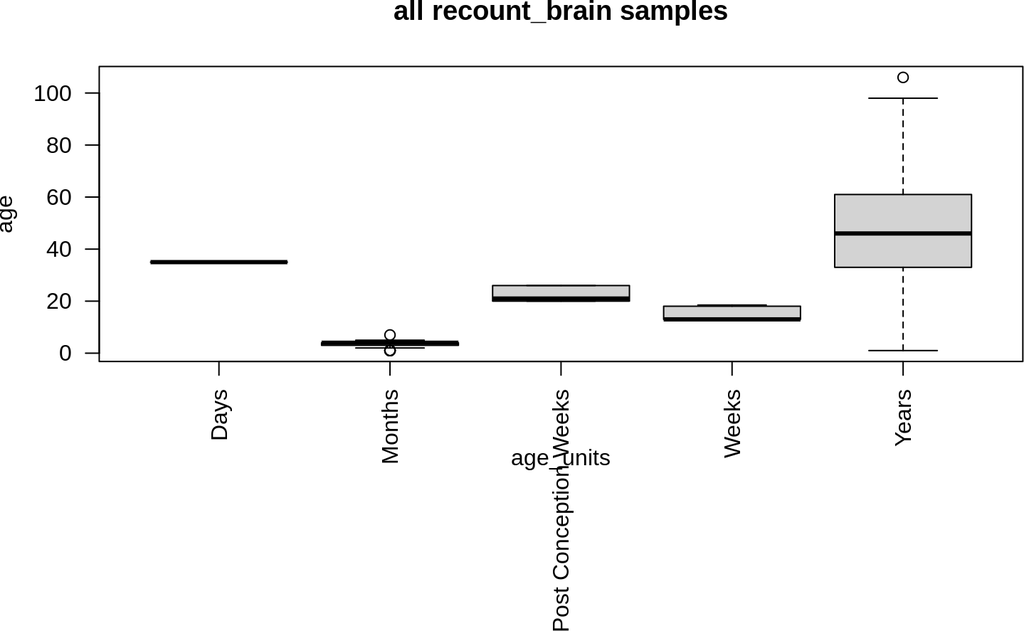

```r
## Age by age units for all samples in recount_brain and then those
## also present in recount
par(mar = c(10, 4, 4, 2) + 0.1)
boxplot(age ~ age_units, data = recount_brain, las = 2,
    main = 'all recount_brain samples')
```

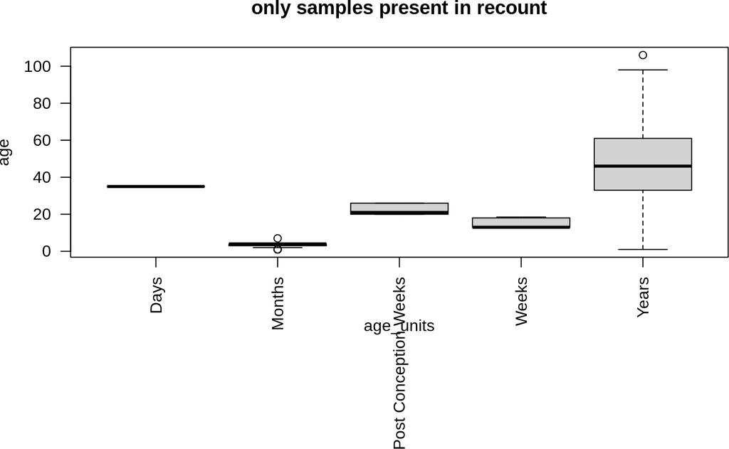

```r
boxplot(age ~ age_units, main = 'only samples present in recount',
    data = recount_brain[recount_brain$present_in_recount, ], las = 2)
```

```r
## Get the number of samples for each boxplot
table(recount_brain$age_units[recount_brain$present_in_recount])
```

```
##
##                  Days                Months Post Conception Weeks
##                     2                    43                    12
##                 Weeks                 Years
##                    16                   899
```

## 6.1 PMI

Here is an example where we explore how many samples have the post mortem interval (PMI) information registered and the relationship with age for those that have age measured in years.

```r
## How many samples have a pmi unit?
table('PMI units' = recount_brain$pmi_units,
    'Present in recount' = recount_brain$present_in_recount, useNA = 'ifany')
```

```
##          Present in recount
## PMI units FALSE TRUE
##     Hours     0  283
##     <NA>   1217 2931
```

```r
## How many samples have a pmi value?
table(!is.na(recount_brain$pmi))
```

```
##
## FALSE  TRUE
##  4149   282
```

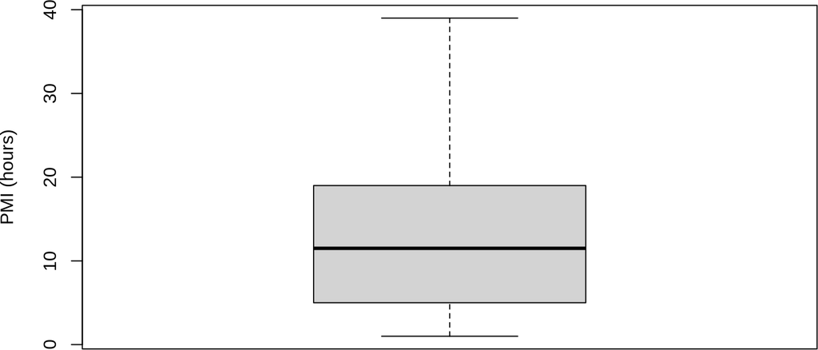

```r
## Check PMI overall
boxplot(recount_brain$pmi, ylab = 'PMI (hours)')
```

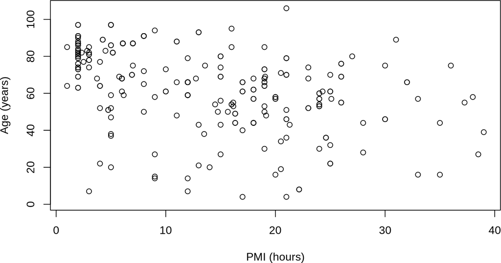

```r
## Compare PMI vs age (in years) for the samples present in recount
plot(age ~ pmi, data = recount_brain[recount_brain$present_in_recount &
    recount_brain$age_units == 'Years', ], ylab = 'Age (years)',
    xlab = 'PMI (hours)')
```

## 6.2 Sex and other variables

Next we can explore the relationship between sex and other variables such as age and disease status.

```r
## Number of observations with sex recorded
table(recount_brain$sex[recount_brain$present_in_recount], useNA = 'ifany')
```

```
##
## female   male pooled   <NA>
##    251    681   1743    539
```

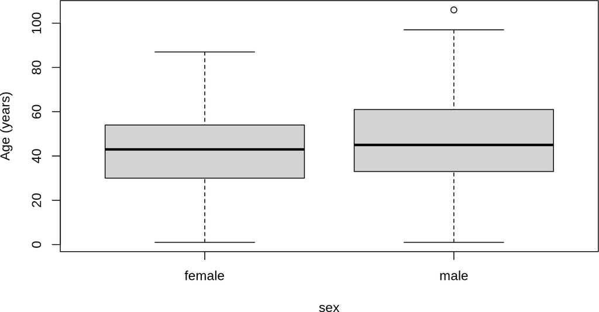

```r
## Age vs sex for those that have age measured in years
boxplot(age ~ sex, data = recount_brain[recount_brain$present_in_recount &
    recount_brain$age_units == 'Years', ], ylab = 'Age (years)')
```

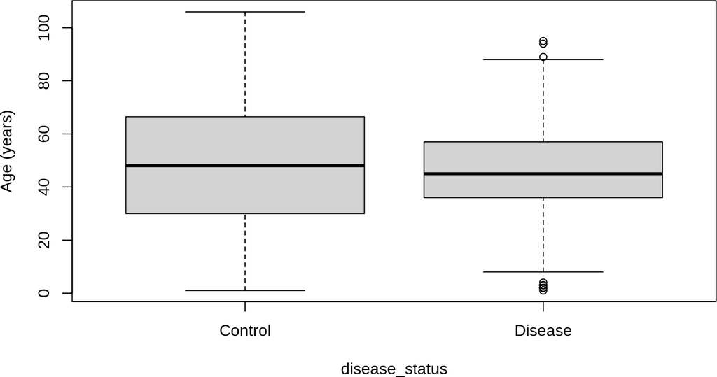

```r
## Check age vs disease status
boxplot(age ~ disease_status,
    data = recount_brain[recount_brain$present_in_recount &
    recount_brain$age_units == 'Years', ], ylab = 'Age (years)')
```

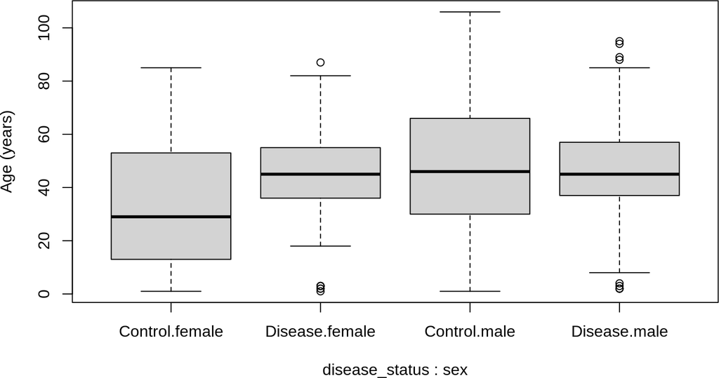

```r
## Check age disease status and sex
boxplot(age ~ disease_status + sex,
    data = recount_brain[recount_brain$present_in_recount &
    recount_brain$age_units == 'Years', ], ylab = 'Age (years)')
```

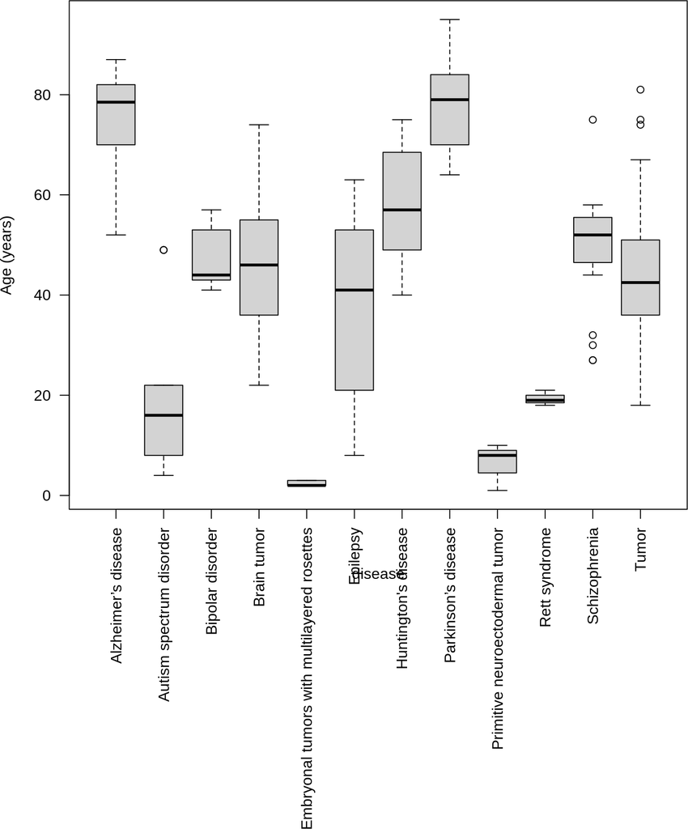

```r
## Age vs the actual disease
par(mar = c(18, 4, 4, 2) + 0.1)
boxplot(age ~ disease, data = recount_brain[recount_brain$present_in_recount &
    recount_brain$age_units == 'Years', ], las = 2, ylab = 'Age (years)')
```

```r
table(recount_brain$disease[recount_brain$present_in_recount &
    recount_brain$age_units == 'Years'], useNA = 'ifany')
```

```
##
##                         Alzheimer’s disease
##                                          16
##                    Autism spectrum disorder
##                                          12
##                            Bipolar disorder
##                                          14
##                                 Brain tumor
##                                          47
## Embryonal tumors with multilayered rosettes
##                                          11
##                                    Epilepsy
##                                          16
##                        Huntington's disease
##                                          32
##                         Parkinson’s disease
##                                          29
##             Primitive neuroectodermal tumor
##                                           3
##                               Rett syndrome
##                                           3
##                               Schizophrenia
##                                          19
##                                       Tumor
##                                         282
##                                        <NA>
##                                        2657
```

# 7 Reproducibility

This document was made possible thanks to:

- R ([R Core Team, 2020](https://www.R-project.org/))
- *BiocStyle* ([Oleś, Morgan, and Huber, 2020](https://github.com/Bioconductor/BiocStyle))
- *devtools* ([Wickham, Hester, and Chang, 2020](https://CRAN.R-project.org/package=devtools))
- *knitcitations* ([Boettiger, 2019](https://CRAN.R-project.org/package=knitcitations))
- *knitr* ([Xie, 2014](http://www.crcpress.com/product/isbn/9781466561595))
- *recount* ([Collado-Torres, Nellore, Kammers, Ellis, et al., 2017](http://www.nature.com/nbt/journal/v35/n4/full/nbt.3838.html))
- *rmarkdown* ([Allaire, Xie, McPherson, Luraschi, et al., 2020](https://github.com/rstudio/rmarkdown))

Code for creating this document

```r
## Create the vignette
library('rmarkdown')
system.time(render('merging_data.Rmd', 'BiocStyle::html_document'))
```

Reproducibility information for this document.

```r
## Reproducibility info
proc.time()
```

```
##    user  system elapsed
##  22.498   2.258  36.396
```

```r
message(Sys.time())
```

```
## 2020-11-13 16:24:13
```

```r
options(width = 120)
```

# 8 Bibliography

This document was generated using *BiocStyle* ([Oleś, Morgan, and Huber, 2020](https://github.com/Bioconductor/BiocStyle)) with *knitr* ([Xie, 2014](http://www.crcpress.com/product/isbn/9781466561595)) and *rmarkdown* ([Allaire, Xie, McPherson, Luraschi, et al., 2020](https://github.com/rstudio/rmarkdown)) running behind the scenes.

Citations made with *knitcitations* ([Boettiger, 2019](https://CRAN.R-project.org/package=knitcitations)) and the bibliographical file is available here.

[1] J. Allaire, Y. Xie, J. McPherson, J. Luraschi, et al. *rmarkdown: Dynamic Documents for R*. R package version 2.5. 2020. <URL: https://github.com/rstudio/rmarkdown>.

[2] C. Boettiger. *knitcitations: Citations for ‘Knitr’ Markdown Files*. R package version 1.0.10. 2019. <URL: https://CRAN.R-project.org/package=knitcitations>.

[3] L. Collado-Torres, A. Nellore, K. Kammers, S. E. Ellis, et al. “Reproducible RNA-seq analysis using recount2”. In: *Nature Biotechnology* (2017). DOI: 10.1038/nbt.3838. <URL: http://www.nature.com/nbt/journal/v35/n4/full/nbt.3838.html>.

[4] A. Oleś, M. Morgan, and W. Huber. *BiocStyle: Standard styles for vignettes and other Bioconductor documents*. R package version 2.16.1. 2020. <URL: https://github.com/Bioconductor/BiocStyle>.

[5] R Core Team. *R: A Language and Environment for Statistical Computing*. R Foundation for Statistical Computing. Vienna, Austria, 2020. <URL: https://www.R-project.org/>.

[6] H. Wickham, J. Hester, and W. Chang. *devtools: Tools to Make Developing R Packages Easier*. R package version 2.3.2. 2020. <URL: https://CRAN.R-project.org/package=devtools>.

[7] Y. Xie. “knitr: A Comprehensive Tool for Reproducible Research in R”. In: *Implementing Reproducible Computational Research*. Ed. by V. Stodden, F. Leisch and R. D. Peng. ISBN 978-1466561595. Chapman and Hall/CRC, 2014. <URL: http://www.crcpress.com/product/isbn/9781466561595>.